### Introduction

This project attempts to analyse the possibility of default on credit card payments in Taiwan. The dataset used was from the UCI archives. Link - https://archive.ics.uci.edu/ml/datasets/default+of+credit+card+clients

#### Imports

```python
import pandas as pd;
import numpy as np;
import seaborn as sns;
import sklearn as sk;
import matplotlib
import matplotlib.pyplot as plt
import seaborn as sns
%matplotlib inline
from sklearn.feature_selection import SelectKBest,chi2,f_classif
from sklearn.model_selection import train_test_split
from sklearn.preprocessing import MinMaxScaler
from sklearn.ensemble import RandomForestClassifier
from sklearn.tree import DecisionTreeClassifier
from sklearn.linear_model import LogisticRegression
from sklearn.neighbors import KNeighborsClassifier
from sklearn.neural_network import MLPClassifier
from sklearn.metrics import accuracy_score
from sklearn.metrics import precision_score
from sklearn.metrics import recall_score
from sklearn.metrics import confusion_matrix
from sklearn.metrics import roc_auc_score
from sklearn.metrics import f1_score
```

### Read Inputs and Examine

```python
# Set console width to max
pd.set_option('display.max_colwidth', 500)
pd.set_option('display.max_rows', 100)

credit = pd.read_csv(r"C:\Users\Dell\Desktop\Assignments\Adv Stats\Project\data.csv")
print(credit.describe().T)
```

```
                              count           mean            std       min  \
ID                          30000.0   15000.500000    8660.398374       1.0
LIMIT_BAL                   30000.0  167484.322667  129747.661567   10000.0
SEX                         30000.0       1.603733       0.489129       1.0
EDUCATION                   30000.0       1.853133       0.790349       0.0
MARRIAGE                    30000.0       1.551867       0.521970       0.0
AGE                         30000.0      35.485500       9.217904      21.0
PAY_0                       30000.0      -0.016700       1.123802      -2.0
PAY_2                       30000.0      -0.133767       1.197186      -2.0
PAY_3                       30000.0      -0.166200       1.196868      -2.0
PAY_4                       30000.0      -0.220667       1.169139      -2.0
PAY_5                       30000.0      -0.266200       1.133187      -2.0
PAY_6                       30000.0      -0.291100       1.149988      -2.0
BILL_AMT1                   30000.0   51223.330900   73635.860576 -165580.0
BILL_AMT2                   30000.0   49179.075167   71173.768783  -69777.0
BILL_AMT3                   30000.0   47013.154800   69349.387427 -157264.0
BILL_AMT4                   30000.0   43262.948967   64332.856134 -170000.0
BILL_AMT5                   30000.0   40311.400967   60797.155770  -81334.0
BILL_AMT6                   30000.0   38871.760400   59554.107537 -339603.0
PAY_AMT1                    30000.0    5663.580500   16563.280354       0.0
PAY_AMT2                    30000.0    5921.163500   23040.870402       0.0
PAY_AMT3                    30000.0    5225.681500   17606.961470       0.0
PAY_AMT4                    30000.0    4826.076867   15666.159744       0.0
PAY_AMT5                    30000.0    4799.387633   15278.305679       0.0
PAY_AMT6                    30000.0    5215.502567   17777.465775       0.0
default payment next month  30000.0       0.221200       0.415062       0.0

                                 25%       50%        75%        max
ID                           7500.75   15000.5   22500.25    30000.0
LIMIT_BAL                   50000.00  140000.0  240000.00  1000000.0
SEX                             1.00       2.0       2.00        2.0
EDUCATION                       1.00       2.0       2.00        6.0
MARRIAGE                        1.00       2.0       2.00        3.0
AGE                            28.00      34.0      41.00       79.0
PAY_0                          -1.00       0.0       0.00        8.0
PAY_2                          -1.00       0.0       0.00        8.0
PAY_3                          -1.00       0.0       0.00        8.0
PAY_4                          -1.00       0.0       0.00        8.0
PAY_5                          -1.00       0.0       0.00        8.0
PAY_6                          -1.00       0.0       0.00        8.0
BILL_AMT1                    3558.75   22381.5   67091.00   964511.0
BILL_AMT2                    2984.75   21200.0   64006.25   983931.0
BILL_AMT3                    2666.25   20088.5   60164.75  1664089.0
BILL_AMT4                    2326.75   19052.0   54506.00   891586.0
BILL_AMT5                    1763.00   18104.5   50190.50   927171.0
BILL_AMT6                    1256.00   17071.0   49198.25   961664.0
PAY_AMT1                     1000.00    2100.0    5006.00   873552.0
PAY_AMT2                      833.00    2009.0    5000.00  1684259.0
PAY_AMT3                      390.00    1800.0    4505.00   896040.0
PAY_AMT4                      296.00    1500.0    4013.25   621000.0
PAY_AMT5                      252.50    1500.0    4031.50   426529.0
PAY_AMT6                      117.75    1500.0    4000.00   528666.0
default payment next month      0.00       0.0       0.00        1.0
```

```python
# Any null values?
print(credit.isnull().sum())
```

```
ID                            0
LIMIT_BAL                     0
SEX                           0
EDUCATION                     0
MARRIAGE                      0
AGE                           0
PAY_0                         0
PAY_2                         0
PAY_3                         0
PAY_4                         0
PAY_5                         0
PAY_6                         0
BILL_AMT1                     0
BILL_AMT2                     0
BILL_AMT3                     0
BILL_AMT4                     0
BILL_AMT5                     0
BILL_AMT6                     0
PAY_AMT1                      0
PAY_AMT2                      0
PAY_AMT3                      0
PAY_AMT4                      0
PAY_AMT5                      0
PAY_AMT6                      0
default payment next month    0
dtype: int64
```

```python
print(pd.Series({c: credit[c].unique() for c in credit}))
```

[output not shown]

[output cut: 9 more lines]

As we continue our analysis, we see that some fields have not been defined in the dataset. For instance, we do not know what EDUCATION fields 5,6 and 0 mean. We could consider adding it to the Others field, i.e. 4. Similarly with MARRIAGE, we do not know what 3 indicates. PAY_0 to PAY_6 also have extra fields of 0 and -2, which are undefined in the dataset.

We could choose to ignore this issue, but if we do, and these unknown fields may be picked up in the train dataset. If their size is substantial, we will be unable to interpret the result. If not, it will contribute to model inaccuracy. If it gets picked up in the test dataset too, it may contribute to overfitting.

```python
print(credit.EDUCATION.value_counts())
print(credit.MARRIAGE.value_counts())
print(credit.PAY_0.value_counts())
```

```
2    14030
1    10585
3     4917
5      280
4      123
6       51
0       14
Name: EDUCATION, dtype: int64
2    15964
1    13659
3      323
0       54
Name: MARRIAGE, dtype: int64
 0    14737
-1     5686
 1     3688
-2     2759
 2     2667
 3      322
 4       76
 5       26
 8       19
 6       11
 7        9
Name: PAY_0, dtype: int64
```

The unknown fields in EDUCATION, MARRIAGE are small in number, and we can safely delete it, since it doesn't make sense and there is already an 'Other' field defined for each of them. However, with PAY_0, we see a large chunk of the data of type 0 and -2. This is seen in all the 'Pay_x' fields.

I shall make a logical assumption here - if 1 refers to Payment delay for 1 month, 2 refers to Payment delay for 2 months, then most likely, 0 refers to Payment on time, -1 refers to Payment made 1 month in advance, -2 refers to Payment made 2 months in advance, with the last two being a debit style payment. To make things simpler, I shall combine 0, -1 and -2 as payment on time or 0, since this study is to do with the probability of default and not early payment of some sort.

```python
credit = credit[(credit.EDUCATION != 5) & (credit.EDUCATION != 6) & (credit.EDUCATION != 0)]
credit = credit[(credit.MARRIAGE != 3)]

print("Before Replacement:\n",credit.PAY_0.value_counts())
credit.PAY_0 = credit['PAY_0'].replace([-1,-2],0)
print("After Replcement:\n",credit.PAY_0.value_counts())
```

```
Before Replacement:
  0    14338
-1     5606
 1     3623
-2     2701
 2     2616
 3      313
 4       76
 5       25
 8       19
 6       11
 7        9
Name: PAY_0, dtype: int64
After Replcement:
 0    22645
1     3623
2     2616
3      313
4       76
5       25
8       19
6       11
7        9
Name: PAY_0, dtype: int64
```

Since this working correctly, I shall do this for all the Pay_x fields

```python
credit.PAY_2 = credit['PAY_2'].replace([-1,-2],0)
credit.PAY_3 = credit['PAY_3'].replace([-1,-2],0)
credit.PAY_4 = credit['PAY_4'].replace([-1,-2],0)
credit.PAY_5 = credit['PAY_5'].replace([-1,-2],0)
credit.PAY_6 = credit['PAY_6'].replace([-1,-2],0)
```

Interestingly, PAY_1 is missing and we have PAY_0

We shall check for correlation within the features, specifically, BILL_AMTx, PAY_AMTx and PAY_x . These groups were chosen for graphical representation after using the Dataframe.corr() method, since the matrix is too big to clearly identify patterns. Rendering all the correlations is also very tedious, hence the 3 sets for visualization were chosen.

```python
corr_df = credit.corr()
print(corr_df)
```

```
                                  ID  LIMIT_BAL       SEX  EDUCATION  \
ID                          1.000000   0.024811  0.020640   0.031343
LIMIT_BAL                   0.024811   1.000000  0.024451  -0.242041
SEX                         0.020640   0.024451  1.000000   0.011298
EDUCATION                   0.031343  -0.242041  0.011298   1.000000
MARRIAGE                   -0.024807  -0.095655 -0.032111  -0.177778
AGE                         0.020006   0.151594 -0.091713   0.183949
PAY_0                      -0.020096  -0.171830 -0.034467   0.065323
PAY_2                      -0.008564  -0.198682 -0.046100   0.075988
PAY_3                      -0.017552  -0.192947 -0.043012   0.067540
PAY_4                       0.014868  -0.181524 -0.040826   0.064303
PAY_5                      -0.019469  -0.171768 -0.039359   0.052632
PAY_6                      -0.031738  -0.169067 -0.033308   0.040500
BILL_AMT1                   0.017688   0.282545 -0.034616   0.006088
BILL_AMT2                   0.016235   0.275653 -0.031938   0.002201
BILL_AMT3                   0.022658   0.280745 -0.025294  -0.002738
BILL_AMT4                   0.038219   0.292624 -0.022746  -0.013222
BILL_AMT5                   0.014841   0.294394 -0.017922  -0.016993
BILL_AMT6                   0.015780   0.288516 -0.017973  -0.014109
PAY_AMT1                    0.006525   0.202874 -0.001557  -0.044965
PAY_AMT2                    0.005454   0.183816 -0.002715  -0.037934
PAY_AMT3                    0.038056   0.217959 -0.011352  -0.051684
PAY_AMT4                    0.006213   0.206762 -0.003773  -0.042635
PAY_AMT5                    0.000438   0.217259 -0.002463  -0.049243
PAY_AMT6                    0.003232   0.219341 -0.002911  -0.052543
default payment next month -0.013836  -0.153870 -0.039528   0.048485

                            MARRIAGE       AGE     PAY_0     PAY_2     PAY_3  \
ID                         -0.024807  0.020006 -0.020096 -0.008564 -0.017552
LIMIT_BAL                  -0.095655  0.151594 -0.171830 -0.198682 -0.192947
SEX                        -0.032111 -0.091713 -0.034467 -0.046100 -0.043012
EDUCATION                  -0.177778  0.183949  0.065323  0.075988  0.067540
MARRIAGE                    1.000000 -0.463788 -0.015222 -0.011518 -0.001469
AGE                        -0.463788  1.000000 -0.002656 -0.008481 -0.014477
PAY_0                      -0.015222 -0.002656  1.000000  0.699774  0.519196
PAY_2                      -0.011518 -0.008481  0.699774  1.000000  0.664559
PAY_3                      -0.001469 -0.014477  0.519196  0.664559  1.000000
PAY_4                      -0.006148 -0.008280  0.461640  0.513528  0.679192
PAY_5                      -0.001965 -0.013120  0.425326  0.462601  0.550638
PAY_6                       0.001144 -0.018012  0.373853  0.406944  0.492392
```

[output cut: 81 more lines]

```
BILL_AMT1                   0.175138                   -0.018837
BILL_AMT2                   0.169982                   -0.013310
BILL_AMT3                   0.179759                   -0.013234
BILL_AMT4                   0.174390                   -0.009357
BILL_AMT5                   0.160976                   -0.005892
BILL_AMT6                   0.114788                   -0.004688
PAY_AMT1                    0.181219                   -0.076808
PAY_AMT2                    0.151538                   -0.060357
PAY_AMT3                    0.154140                   -0.057692
PAY_AMT4                    0.150724                   -0.057574
PAY_AMT5                    0.156622                   -0.055748
PAY_AMT6                    1.000000                   -0.054218
default payment next month -0.054218                    1.000000

[25 rows x 25 columns]
```

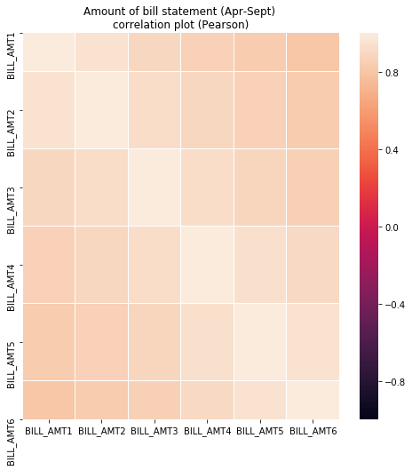

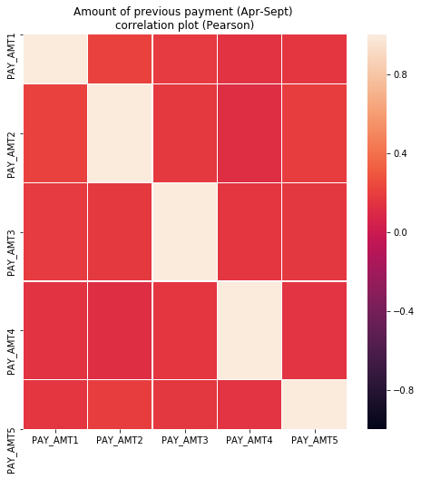

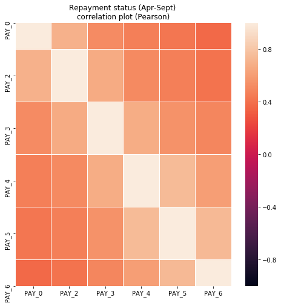

```python
var = ['BILL_AMT1','BILL_AMT2','BILL_AMT3','BILL_AMT4','BILL_AMT5','BILL_AMT6']

plt.figure(figsize = (8,8))
plt.title('Amount of bill statement (Apr-Sept) \ncorrelation plot (Pearson)')
corr = credit[var].corr()
sns.heatmap(corr,xticklabels=corr.columns,yticklabels=corr.columns,linewidths=.1,vmin=-1, vmax=1)
plt.show()

var = ['PAY_AMT1', 'PAY_AMT2', 'PAY_AMT3', 'PAY_AMT4', 'PAY_AMT5']

plt.figure(figsize = (8,8))
plt.title('Amount of previous payment (Apr-Sept) \ncorrelation plot (Pearson)')
corr = credit[var].corr()
sns.heatmap(corr,xticklabels=corr.columns,yticklabels=corr.columns,linewidths=.1,vmin=-1, vmax=1)
plt.show()

var = ['PAY_0','PAY_2', 'PAY_3', 'PAY_4', 'PAY_5', 'PAY_6']
plt.figure(figsize = (8,8))
plt.title('Repayment status (Apr-Sept) \ncorrelation plot (Pearson)')
corr = credit[var].corr()
sns.heatmap(corr,xticklabels=corr.columns,yticklabels=corr.columns,linewidths=.1,vmin=-1, vmax=1)
plt.show()
```

We can see that PAY_x and BILL_AMTx have high correlation and can be dropped. I will only retain PAY_0, PAY_6 (correlation is less than 0.5) and BILL_AMT1. Since we have already adjusted for correlation, I shall not perform PCA. Next, we shall create dummy variables for the categorical fields and split the dataset. Since there is no instruction, I shall split it 2/3rd:1/3rd and perform MinMax Scaling. I will not scale the categorical y since it is senseless. This also means that I do not need to inverse transform the scaling.

```python
categs=['SEX', 'EDUCATION', 'MARRIAGE', 'PAY_0', 'PAY_2', 'PAY_3', 'PAY_4', 'PAY_5', 'PAY_6']
for c in categs:
    credit[c]=credit[c].astype('category')
credit_wd=pd.get_dummies(credit, drop_first=True)

y=credit_wd['default payment next month']
X_=credit_wd.drop(columns=['default payment next month'])

X = X_.loc[:,['LIMIT_BAL', 'AGE', 'BILL_AMT1', 'PAY_AMT1', 'PAY_AMT2', 'PAY_AMT3', 'PAY_AMT4', 'PAY_AMT5', 'PAY_AMT6', 'SEX_2', 'EDUCATION_2', 'EDUCATION_3', 'EDUCATION_4', 'MARRIAGE_1', 'MARRIAGE_2', 'PAY_0_1', 'PAY_0_2', 'PAY_0_3', 'PAY_0_4', 'PAY_0_5', 'PAY_0_6', 'PAY_0_7', 'PAY_0_8', 'PAY_6_2', 'PAY_6_3', 'PAY_6_4', 'PAY_6_5', 'PAY_6_6', 'PAY_6_7', 'PAY_6_8']
]

X_train, X_test, y_train, y_test = train_test_split(X, y, stratify=y, random_state=1, test_size=0.33)
minMaxScaler = MinMaxScaler(feature_range=(0, 1));
X_train = minMaxScaler.fit_transform(X_train);
X_test = minMaxScaler.transform(X_test);
```

### Algorithms

Since this is a classification problem, we can use Logistical Regression, Random Forests, Decision Trees, k Nearest Neighbours and Neural Network to classify. In order to decide which is optimal, I shall run all of them and see which performs better than the others. First, Logistic Regression

```python
mod_lin = LogisticRegression(solver='lbfgs',random_state=1,max_iter=250)
mod_lin.fit(X_train, y_train)

print("Log Reg - Training metrics")
print('Accuracy:', accuracy_score(y_train, mod_lin.predict(X_train)))
print('Precision:', precision_score(y_train, mod_lin.predict(X_train)))
print('Recall:', recall_score(y_train, mod_lin.predict(X_train)))
print("Conf Matrix:\n", sk.metrics.confusion_matrix(pd.DataFrame(y_train),pd.DataFrame(mod_lin.predict(X_train))))

print("Log Reg - Testing metrics")
print('Accuracy:', accuracy_score(y_test, mod_lin.predict(X_test)))
print('Precision:', precision_score(y_test, mod_lin.predict(X_test)))
print('Recall:', recall_score(y_test, mod_lin.predict(X_test)))
print("Conf Matrix:\n", sk.metrics.confusion_matrix(pd.DataFrame(y_test),pd.DataFrame(mod_lin.predict(X_test))))
print('AUC:',roc_auc_score(y_test, mod_lin.predict(X_test)))
print('F1 Score:',f1_score(y_test, mod_lin.predict(X_test)))
```

```
Log Reg - Training metrics
Accuracy: 0.8188756041719665
Precision: 0.6807658058771149
Recall: 0.3497255260750229
Conf Matrix:
 [[14566   717]
 [ 2843  1529]]
Log Reg - Testing metrics
Accuracy: 0.8217310473042759
Precision: 0.6938405797101449
Recall: 0.3556174558960074
Conf Matrix:
 [[7190  338]
 [1388  766]]
AUC: 0.655359206162669
F1 Score: 0.47022713321055865
```

Straight away, we see that the Logistic Regression performs well, with high testing and training accuracy. There is no overfitting. We see a good AUC of 0.655 and F1 score of 0.47. We shall check if RandomForest beats this model.

```python
rf=RandomForestClassifier(random_state=1,criterion='entropy',n_estimators=50,verbose=False)
rf.fit(X_train, y_train)

print('Random Forest - Training set metrics:')
print('Accuracy:', accuracy_score(y_train, rf.predict(X_train)))
print('Precision:', precision_score(y_train, rf.predict(X_train)))
print('Recall:', recall_score(y_train, rf.predict(X_train)))
print("Conf Matrix:\n", confusion_matrix(pd.DataFrame(y_train),pd.DataFrame(rf.predict(X_train))))

print('Random Forest - Test set metrics:')
print('Accuracy:', accuracy_score(y_test, rf.predict(X_test)))
print('Precision:', precision_score(y_test, rf.predict(X_test)))
print('Recall:', recall_score(y_test, rf.predict(X_test)))
print("Conf Matrix:\n", confusion_matrix(pd.DataFrame(y_test),pd.DataFrame(rf.predict(X_test))))
```

```
Random Forest - Training set metrics:
Accuracy: 0.9989824472144493
Precision: 0.9993116108306562
Recall: 0.9961116193961573
Conf Matrix:
 [[15280     3]
 [   17  4355]]
Random Forest - Test set metrics:
Accuracy: 0.8168766783722371
Precision: 0.6717763751127142
Recall: 0.3458681522748375
Conf Matrix:
 [[7164  364]
 [1409  745]]
```

There is overfitting of the data, so I shall try some combinations to overcome it

```python
rf=RandomForestClassifier(random_state=1,n_estimators=50,criterion='entropy',max_depth=10,verbose=False)
rf.fit(X_train, y_train)

print('Random Forest - Training set metrics:')
print('Accuracy:', accuracy_score(y_train, rf.predict(X_train)))
print('Precision:', precision_score(y_train, rf.predict(X_train)))
print('Recall:', recall_score(y_train, rf.predict(X_train)))
print("Conf Matrix:\n", confusion_matrix(pd.DataFrame(y_train),pd.DataFrame(rf.predict(X_train))))

print('Random Forest - Test set metrics:')
print('Accuracy:', accuracy_score(y_test, rf.predict(X_test)))
print('Precision:', precision_score(y_test, rf.predict(X_test)))
print('Recall:', recall_score(y_test, rf.predict(X_test)))
print("Conf Matrix:\n", confusion_matrix(pd.DataFrame(y_test),pd.DataFrame(rf.predict(X_test))))
```

```
Random Forest - Training set metrics:
Accuracy: 0.839379292800814
Precision: 0.8182294394971189
Recall: 0.3572735590118939
Conf Matrix:
 [[14936   347]
 [ 2810  1562]]
Random Forest - Test set metrics:
Accuracy: 0.8191489361702128
Precision: 0.7092419522326064
Recall: 0.31708449396471683
Conf Matrix:
 [[7248  280]
 [1471  683]]
```

```python
rf=RandomForestClassifier(random_state=1,n_estimators=200,criterion='entropy',max_depth=5,verbose=False)
rf.fit(X_train, y_train)

print('Random Forest - Training set metrics:')
print('Accuracy:', accuracy_score(y_train, rf.predict(X_train)))
print('Precision:', precision_score(y_train, rf.predict(X_train)))
print('Recall:', recall_score(y_train, rf.predict(X_train)))
print("Conf Matrix:\n", confusion_matrix(pd.DataFrame(y_train),pd.DataFrame(rf.predict(X_train))))

print('Random Forest - Test set metrics:')
print('Accuracy:', accuracy_score(y_test, rf.predict(X_test)))
print('Precision:', precision_score(y_test, rf.predict(X_test)))
print('Recall:', recall_score(y_test, rf.predict(X_test)))
print("Conf Matrix:\n", confusion_matrix(pd.DataFrame(y_test),pd.DataFrame(rf.predict(X_test))))
print("AUC:", roc_auc_score(y_test, rf.predict(X_test)))
print('F1 Score:',f1_score(y_test, rf.predict(X_test)))
```

```
Random Forest - Training set metrics:
Accuracy: 0.8098193843805648
Precision: 0.7737478411053541
Recall: 0.20494053064958828
Conf Matrix:
 [[15021   262]
 [ 3476   896]]
Random Forest - Test set metrics:
Accuracy: 0.8051022516009089
Precision: 0.738819320214669
Recall: 0.19173630454967502
Conf Matrix:
 [[7382  146]
 [1741  413]]
AUC: 0.586171021562829
F1 Score: 0.304460007371913
```

After trying different combinations of parameters, this is the best combination that I could find, with barely no overfitting. This model performs similarly to the Logistical Regression in terms of Accuracy, however, with a very low recall score, it has a lower AUC and F1 score than Logistical Regression. Next, we shall check k-Nearest Neighbor.

```python
knn = KNeighborsClassifier(n_neighbors=8, leaf_size=30,metric='minkowski', algorithm= 'auto')
knn.fit(X_train, y_train)

print('kNN - Training set metrics:')
print('Accuracy:', accuracy_score(y_train, knn.predict(X_train)))
print('Precision:', precision_score(y_train, knn.predict(X_train)))
print('Recall:', recall_score(y_train, knn.predict(X_train)))
print("Conf Matrix:\n", confusion_matrix(pd.DataFrame(y_train),pd.DataFrame(knn.predict(X_train))))

print('kNN - Test set metrics:')
print('Accuracy:', accuracy_score(y_test, knn.predict(X_test)))
print('Precision:', precision_score(y_test, knn.predict(X_test)))
print('Recall:', recall_score(y_test, knn.predict(X_test)))
print("Conf Matrix:\n", confusion_matrix(pd.DataFrame(y_test),pd.DataFrame(knn.predict(X_test))))
print("AUC:", roc_auc_score(y_test, knn.predict(X_test)))
print('F1 Score:',f1_score(y_test, knn.predict(X_test)))
```

```
kNN - Training set metrics:
Accuracy: 0.825642330195879
Precision: 0.7333333333333333
Recall: 0.3396614821591949
Conf Matrix:
 [[14743   540]
 [ 2887  1485]]
kNN - Test set metrics:
Accuracy: 0.80882049163396
Precision: 0.6498516320474778
Recall: 0.3050139275766017
Conf Matrix:
 [[7174  354]
 [1497  657]]
AUC: 0.6289947427468556
F1 Score: 0.4151658767772512
```

```python
dt = DecisionTreeClassifier(max_depth=7, random_state=1)
dt.fit(X_train, y_train)

print('Decision Tree - Training set metrics:')
print('Accuracy:', accuracy_score(y_train, dt.predict(X_train)))
print('Precision:', precision_score(y_train, dt.predict(X_train)))
print('Recall:', recall_score(y_train, dt.predict(X_train)))
print("Conf Matrix:\n", confusion_matrix(pd.DataFrame(y_train),pd.DataFrame(dt.predict(X_train))))

print('Decision Tree - Test set metrics:')
print('Accuracy:', accuracy_score(y_test, dt.predict(X_test)))
print('Precision:', precision_score(y_test, dt.predict(X_test)))
print('Recall:', recall_score(y_test, dt.predict(X_test)))
print("Conf Matrix:\n", confusion_matrix(pd.DataFrame(y_test),pd.DataFrame(dt.predict(X_test))))
print("AUC:", roc_auc_score(y_test, dt.predict(X_test)))
print('F1 Score:',f1_score(y_test, dt.predict(X_test)))
```

```
Decision Tree - Training set metrics:
Accuracy: 0.8248282879674383
Precision: 0.7393096342091705
Recall: 0.3282250686184812
Conf Matrix:
 [[14777   506]
 [ 2937  1435]]
Decision Tree - Test set metrics:
Accuracy: 0.8190456517248502
Precision: 0.7147435897435898
Recall: 0.31058495821727017
Conf Matrix:
 [[7261  267]
 [1485  669]]
AUC: 0.6375586852722908
F1 Score: 0.4330097087378641
```

This method has done better than kNN, but is still short of the F1 scores and AUC values of Logistic Regression. It is interesting to see that the simplest algorithm has the best performance yet. Lastly, Neural Network

```python
mlp = MLPClassifier(hidden_layer_sizes=(400,200,100), activation='relu', solver='lbfgs', random_state=1, verbose=False)
mlp.fit(X_train, y_train)


print('Neural Network - Training set metrics:')
print('Accuracy:', accuracy_score(y_train, mlp.predict(X_train)))
print('Precision:', precision_score(y_train, mlp.predict(X_train)))
print('Recall:', recall_score(y_train, mlp.predict(X_train)))
print("Conf Matrix:\n", confusion_matrix(pd.DataFrame(y_train),pd.DataFrame(mlp.predict(X_train))))

print('Neural Network - Test set metrics:')
print('Accuracy:', accuracy_score(y_test, mlp.predict(X_test)))
print('Precision:', precision_score(y_test, mlp.predict(X_test)))
print('Recall:', recall_score(y_test, mlp.predict(X_test)))
print("Conf Matrix:\n", confusion_matrix(pd.DataFrame(y_test),pd.DataFrame(mlp.predict(X_test))))
print("AUC:", roc_auc_score(y_test, mlp.predict(X_test)))
print('F1 Score:',f1_score(y_test, mlp.predict(X_test)))
```

```
Neural Network - Training set metrics:
Accuracy: 0.8224370389213941
Precision: 0.6884615384615385
Recall: 0.36848124428179324
Conf Matrix:
 [[14554   729]
 [ 2761  1611]]
Neural Network - Test set metrics:
Accuracy: 0.8210080561867382
Precision: 0.6822510822510822
Recall: 0.3658310120705664
Conf Matrix:
 [[7161  367]
 [1366  788]]
AUC: 0.6585398418482481
F1 Score: 0.47627682079177996
```

Finally, we see that the Neural Network has outperformed the Logistical Regression. Although Recall scores are still on the low side, it has a high accuracy, a moderate precision, and the highest AUC and F1 scores so far. There is also no overfitting.

To understand the contribution of each variable in the regression, we need to check correlations between variables and target, I have used Chi Squared Test for the categorical variables and Anova f test for continuous variables. I am using SelectKBest, which gives me the best k features by using Chi Squared and F tests. If the value of the tests are high, it means that the feature and target variable are highly correlated & their relative variance is high. I have also set k to 'all', to give me the complete list of features with their performance.

```python
print(list(X.columns))
X_cont = X.loc[:,['LIMIT_BAL','BILL_AMT1','PAY_AMT1','PAY_AMT2','PAY_AMT3','PAY_AMT4','PAY_AMT5','PAY_AMT6']] #Continuous variables
X_cate = X.iloc[:,9:] #Categorical Variables
fs_cont = SelectKBest(score_func=f_classif, k='all')
fs_cont.fit(X_cont,y)
print('F test with pvalues')
for i in range(len(fs_cont.scores_)):
    print('%s: %f - %f' % (X_cont.columns[i], fs_cont.scores_[i], fs_cont.pvalues_[i]))

fs_cat = SelectKBest(score_func=chi2, k='all')
fs_cat.fit(X_cate,y)
print('Chi 2 test with pvalues')
for i in range(len(fs_cat.scores_)):
    print('%s: %f - %f' % (X_cate.columns[i], fs_cat.scores_[i], fs_cat.pvalues_[i]))
```

```
['LIMIT_BAL', 'AGE', 'BILL_AMT1', 'PAY_AMT1', 'PAY_AMT2', 'PAY_AMT3', 'PAY_AMT4', 'PAY_AMT5', 'PAY_AMT6', 'SEX_2', 'EDUCATION_2', 'EDUCATION_3', 'EDUCATION_4', 'MARRIAGE_1', 'MARRIAGE_2', 'PAY_0_1', 'PAY_0_2', 'PAY_0_3', 'PAY_0_4', 'PAY_0_5', 'PAY_0_6', 'PAY_0_7', 'PAY_0_8', 'PAY_6_2', 'PAY_6_3', 'P…
F test with pvalues
LIMIT_BAL: 711.378879 - 0.000000
BILL_AMT1: 10.413024 - 0.001253
PAY_AMT1: 174.088032 - 0.000000
PAY_AMT2: 107.256598 - 0.000000
PAY_AMT3: 97.965082 - 0.000000
PAY_AMT4: 97.562691 - 0.000000
PAY_AMT5: 91.452910 - 0.000000
PAY_AMT6: 86.486754 - 0.000000
Chi 2 test with pvalues
SEX_2: 18.171789 - 0.000020
EDUCATION_2: 16.854822 - 0.000040
EDUCATION_3: 23.246880 - 0.000001
EDUCATION_4: 18.686321 - 0.000015
MARRIAGE_1: 16.153533 - 0.000058
MARRIAGE_2: 12.795866 - 0.000347
PAY_0_1: 292.410051 - 0.000000
PAY_0_2: 3387.616261 - 0.000000
PAY_0_3: 536.165453 - 0.000000
PAY_0_4: 93.688916 - 0.000000
PAY_0_5: 12.796803 - 0.000347
PAY_0_6: 6.635160 - 0.009999
PAY_0_7: 16.046567 - 0.000062
PAY_0_8: 13.960712 - 0.000187
PAY_6_2: 1285.088573 - 0.000000
PAY_6_3: 186.631520 - 0.000000
PAY_6_4: 44.969914 - 0.000000
PAY_6_5: 7.505691 - 0.006150
PAY_6_6: 25.993075 - 0.000000
PAY_6_7: 93.589255 - 0.000000
PAY_6_8: 6.990806 - 0.008193
```

We immediately see that LIMIT_BAL has a massive F test value, indicating that the output variable is largely controlled by this feature. Similarly, we see that PAY_0_2, PAY_6_2 and PAY_0_3 have a significant effect as well. As a quick test, I shall run a Logistic Regression with only these parameters and observe their results.

```python
X_ = X_.loc[:,['LIMIT_BAL','PAY_0_2','PAY_6_2','PAY_0_3']]
X_train, X_test, y_train, y_test = train_test_split(X_, y, stratify=y, random_state=1, test_size=0.33)

minMaxScaler = MinMaxScaler(feature_range=(0, 1));
X_train = minMaxScaler.fit_transform(X_train);
X_test = minMaxScaler.transform(X_test);

mod_lin = LogisticRegression(solver='lbfgs',random_state=1,max_iter=250)
mod_lin.fit(X_train, y_train)

print("Log Reg - Training metrics")
print('Accuracy:', accuracy_score(y_train, mod_lin.predict(X_train)))
print('Precision:', precision_score(y_train, mod_lin.predict(X_train)))
print('Recall:', recall_score(y_train, mod_lin.predict(X_train)))
print("Conf Matrix:\n", sk.metrics.confusion_matrix(pd.DataFrame(y_train),pd.DataFrame(mod_lin.predict(X_train))))

print("Log Reg - Testing metrics")
print('Accuracy:', accuracy_score(y_test, mod_lin.predict(X_test)))
print('Precision:', precision_score(y_test, mod_lin.predict(X_test)))
print('Recall:', recall_score(y_test, mod_lin.predict(X_test)))
print("Conf Matrix:\n", sk.metrics.confusion_matrix(pd.DataFrame(y_test),pd.DataFrame(mod_lin.predict(X_test))))
print('AUC:',roc_auc_score(y_test, mod_lin.predict(X_test)))
print('F1 Score:',f1_score(y_test, mod_lin.predict(X_test)))
```

```
Log Reg - Training metrics
Accuracy: 0.8165861104044773
Precision: 0.699843668577384
Recall: 0.30718206770356815
Conf Matrix:
 [[14707   576]
 [ 3029  1343]]
Log Reg - Testing metrics
Accuracy: 0.8184259450526751
Precision: 0.7101910828025477
Recall: 0.31058495821727017
Conf Matrix:
 [[7255  273]
 [1485  669]]
AUC: 0.6371601730512494
F1 Score: 0.4321705426356589
```

### Conclusion

To summarize, we analysed the data for undefined values and adjusted for them, and checked for missing data. Then, we examined correlation between features and built heatmaps for groups of data that were suspect. After eliminating these features and scaling the rest, we ran Logistical, Random Forest, k-NN, Decision Trees and Neural Network, to check which model fit the classification the best. The models were tested with testing dataset and adjusted for overfitting.

With the results of the analysis, we see that the Neural Network performs the best for this dataset, with an accuracy of 82.1% and F1 score of 0.476. AUC score is also the highest at 65.85%. But the far simpler Logistic Regression may also be examined for a lightweight model with similar results. Additionally, we also see that the features - 'LIMIT_BAL','PAY_0_2','PAY_6_2','PAY_0_3' have the most correlation with the Default Variable and an extension of this project could be to re-examine each algorithm with these features alone.